# Unified Model: Mixed effects ordinal regression

# Overview

A quick summary of the regression results. Two models, one with and one without interaction effects. As well as model comparison to see if they are different.

Lastly, the plots show the interaction effects on the marginal probabilities.

# Fully specified model

These are the results of the fully specified unified model. The fact that territorial Level is signficant only in the interaction is not a problem at all -it’s effect was being masked by the Frames and to a lesser extent by Actor. All the more justification for running an interaction model.

|  | Dependent Variable: Tone |
| --- | --- |
| Level: ref=National | -0.103 (-0.304) |
| Frame: ref=Politics | -3.576 *** (-10.078) |
| Actor: ref=EU/Other | 0.365 (1.100) |
| Net balance p.c. | 0.002 (0.884) |
| EU good thing (average) | -1.253 (-0.677) |
| Quality governance | 0.429 (1.070) |
| Level self rule | 0.015 (0.300) |
| Word length (500:1000) | -0.452 ** (-2.626) |
| Word length (+1000) | -1.169 *** (-4.006) |
| Year | -0.129 (-1.189) |
| Type:Web native | 0.073 (0.327) |
| Level * Frame | 1.268 *** (3.315) |
| Level * Actor | -1.085 ** (-2.730) |
| Mixed effects ordinal regression (z values in brackets). Significant coefficients <0.05 in bold. P-value signficance levels: *** p < 0.001; ** p < 0.01; * p < 0.05. |  |

# Plots

Here we look at the 3 key variables (Level / Actor / Frame)

What to look for in the plots. Horizontal lines indicate No difference between territorial levels (i.e., National and Regional are nearly on same level). Where lines go up or down indicates differences between territorial leves. Also, check which region of the plot that lines are, in the High probability regaion or the Low probability region.

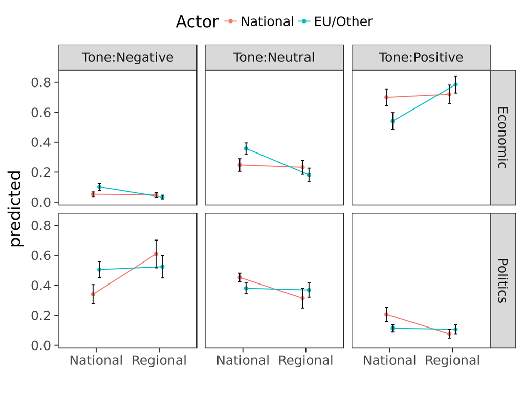

Note: For the Actor dummy, national/subnational/local is called “National”, EU (as well as national, and other) is called “EU/Other”.

A quick interpretation taking each Tone separately:

For *negative tone*, first of all stories in the Eco frame are very, very unlikely to be negative. There’s not much of a discernable difference in the Eco frame between the territorial levels -although Regional referencing EU/Other is the most unlikely when compared to National level. There are big differences with the Politics frame, and this difference is relates to actor. Regional news sources are more likely to have a negative story referencing to National actors, while this is less likely for National level sources. Regarding EU actors in the negative Politics frame, there’s no difference.

For *Neutral tone*, for the Eco frame the difference between territorial levels is with regard to EU Actos -less likely for regional sources to be referencing these in this neutral category. (the reason why is because they are likely to be in the positive tone, see next plot). In the Politics frame no discernable difference regarding the referencing of EU/other actors appears, although there is a slight difference with regard to the referencing of National actors across levels in the neutral tone.

For *Positive tone*, the obvious difference is the likelihood of being Positive is very different across the two Frames. Yet there are some important differences between the territorial levels. In the Eco frame, there is no real difference between territorial levels when it comes to referencing “National actors only”. However, Regional sources are considerably more likely to mention EU/other actors in the positive Eco frame than National sources. In the Politics frame the opposite is the case. Its very unlikely for Politics frames to be positive. Interestingly, regional sources are more unlikely to be referencing National actors in the Positive political frame than national sources, while for referencing “EU/other actors” there’s no difference between the levels in the politics frame.

# Annex

### Model 1 without interaction: Regression output

```
## Cumulative Link Mixed Model fitted with the Laplace approximation
##
## formula: Tone ~ level + dim + Actor1 + net_bal_pc + goodMu + equi17 +
##     selfrule + words + year2 + sourceFormat + (1 | country) +
##     (1 | site)
## data:    df
##
##  link  threshold nobs logLik  AIC     niter      max.grad cond.H
##  logit flexible  970  -788.46 1606.92 1201(3783) 9.34e-03 5.6e+06
##
## Random effects:
##  Groups  Name        Variance Std.Dev.
##  site    (Intercept) 0.7402   0.8604
##  country (Intercept) 0.1834   0.4282
## Number of groups:  site 226,  country 8
##
## Coefficients:
##                          Estimate Std. Error z value Pr(>|z|)
## levelNational           -0.244645   0.222379  -1.100  0.27128
## dimPolitics             -2.619506   0.192925 -13.578  < 2e-16 ***
## Actor1EU/Other          -0.403498   0.182970  -2.205  0.02744 *
## net_bal_pc               0.001846   0.002261   0.816  0.41433
## goodMu                  -1.338174   1.868175  -0.716  0.47381
## equi17                   0.412491   0.405253   1.018  0.30874
## selfrule                 0.017034   0.048958   0.348  0.72790
## words500-1000           -0.445882   0.170736  -2.612  0.00901 **
## words+1000              -1.154887   0.289160  -3.994  6.5e-05 ***
## year2                   -0.136608   0.108063  -1.264  0.20618
## sourceFormatOnline only  0.084735   0.223075   0.380  0.70406
## ---
## Signif. codes:  0 '***' 0.001 '**' 0.01 '*' 0.05 '.' 0.1 ' ' 1
##
## Threshold coefficients:
##                  Estimate Std. Error z value
## Negative|Neutral  -4.3539     0.9788  -4.448
## Neutral|Positive  -2.2637     0.9671  -2.341
## (15 observations deleted due to missingness)
```

### Model 2 interaction: Regression output

[output not shown]

### Comparison of model

| no.par | AIC | logLik | LR.stat | df | Pr(>Chisq) |
| --- | --- | --- | --- | --- | --- |
| 15 | 1.61e+03 | -788 |  |  |  |
| 17 | 1.6e+03 | -781 | 14.8 | 2 | 0.00061 |

The comparison of models shows that the interaction model is better (lower AIC and there’s a signficant difference) between the two.